# Simulating disease transmission (Part 3)

Hector Marina

## Introduction

This practical extends the previous disease-transmission simulations by introducing explicit contact networks and genetic differences among individuals. First, we will use `SimNet` to simulate transmission through alternative temporal contact structures and evaluate which network best explains observed infection events. We will then incorporate breeding values for susceptibility and infectivity to explore how genetic selection may influence disease transmission and population-level prevalence.

1. Network-based transmission models
2. Incorporating breeding values into transmission models

### Required packages

```r
#remotes::install_github("Hector-Marina/SimNet", dependencies=TRUE, build_vignettes=TRUE)
library(SimNet)
```

## Network-based transmission models

The individual-based models introduced previously assume that infection risk depends on the number of infectious individuals to which a susceptible individual is exposed. However, in real populations, individuals do not necessarily interact equally with every other individual.

*Network-based transmission models* explicitly represent these potential transmission pathways. Individuals are represented as nodes, while connections between individuals represent opportunities for pathogen transmission. These connections can differ in their strength, direction, and persistence through time.

Here, we will use the `SimNet` package to simulate different temporal contact structures and investigate how they affect disease transmission.

```r
library(SimNet)
```

We begin, once more, by fixing a random seed to make the stochastic simulations reproducible.

```r
set.seed(123)
```

The complete `SimNet` workflow and additional examples can be explored using the package vignette:

```r
browseVignettes("SimNet")
```

`SimNet` uses a simulation object that is progressively updated as population information, contact networks, and transmission events are added, following a similar object-based workflow to that used in `AlphaSimR`.

### Create the population

We first create a population of 200 individuals followed for 100 time steps (previous `nsteps`). The simulation will be repeated 100 times (a.k.a. replicates).

```r
POP=simplePOP(
  NIDs=200,  # Number of individuals
  steps=100, # Number of steps (nsteps)
  rep=100)   # Total replicates
POP
```

```
## -------simulated POPulation object-------
## Number of individuals: 200
## Individuals information: FALSE
## Number of steps: 100
## Number of replicates: 100
## Contact matrices: FALSE
## Transmission information: FALSE
## Transmission pathway information: FALSE
```

The `simPOP` object will progressively store the contact networks, infection histories, and transmission information generated during the simulation.

### Direct contact networks

We first simulate a weighted temporal contact network representing opportunities for direct transmission between individuals. `simCONT()` generates contact weights from a gamma distribution. Here, `gshape = 1` and `gscale = 5` produce a right-skewed distribution with a mean contact weight of 5 and a long tail of stronger contacts. The parameter `rho = 0.25` introduces correlation between the contact weights of consecutive time steps. This parameters from social networks have been derived from [Marina et al., (2024)](https://doi.org/10.1016/J.APPLANIM.2024.106366).

```r
POP=simCONT(
  POP=POP,        # Population object
  NameCont="SIN", # Name of the contact network (Social Interaction Network)
  gshape=1,       # Contact weights parameters
  gscale=5,
  val=1,          # Multiplicative scaling factor for the simulated values
  rho=0.25        # Correlation between networks
)
```

Weighted direct-contact networks can represent differences in the frequency, duration, or intensity of interactions between animals. For example, [de Freslon et al. (2019)](https://doi.org/10.1016/J.APPLANIM.2019.01.006) used behavioral contact networks in dairy cattle to investigate contacts potentially relevant for direct transmission of *Leptospira*.

We can visualize the contact weights during the first simulation step. Darker cells indicate stronger contact between two individuals.

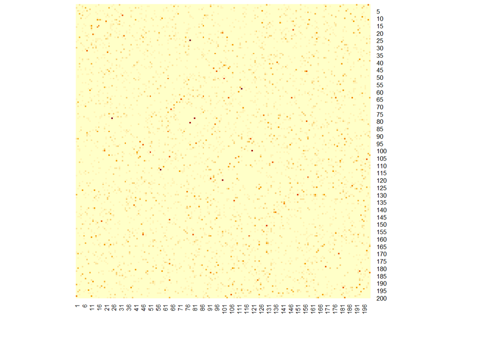

```r
heatmap(POP@ContactM[["SIN"]][[1]],
        Colv = NA, Rowv = NA, symm = TRUE, revC = TRUE)
```

The matrix is symmetric because a distance proximity contact between individuals $i$ and $j$ is assumed to represent the same connection in both directions:

$$\phi_{ij}=\phi_{ji}.$$

### Object-mediated contact networks

Pathogens can also be transmitted indirectly through shared objects or environmental locations. In this case, two individuals do not need to be present at the same time. `simOBJ()` simulates this process by recording the sequential use of shared objects. Here, individuals use 24 possible milking positions twice per simulation step.

```r
POP=simOBJ(POP=POP,
  NameCont="MPN", # Name of the contact network (Milking Parlour Network)
  pos=24,         # Available positions
  freq=2,         # Number of uses per individuals (Two milkings)
  val=12          # Multiplicative scaling factor for the simulated values
)
```

This network can represent a pathogen deposited by one animal at a milking position and subsequently acquired by another animal using the same position.

A similar concept occurs in environmental transmission of chronic wasting disease in white-tailed deer. [Egan et al. (2023)](https://doi.org/10.1002/ecs2.4434) investigated indirect contact through shared deer scrapes, where infectious material deposited by one individual may later expose another individual.

We can again visualize the contact matrix, in this case using the function `plot()` to represent the contact matrix as a network

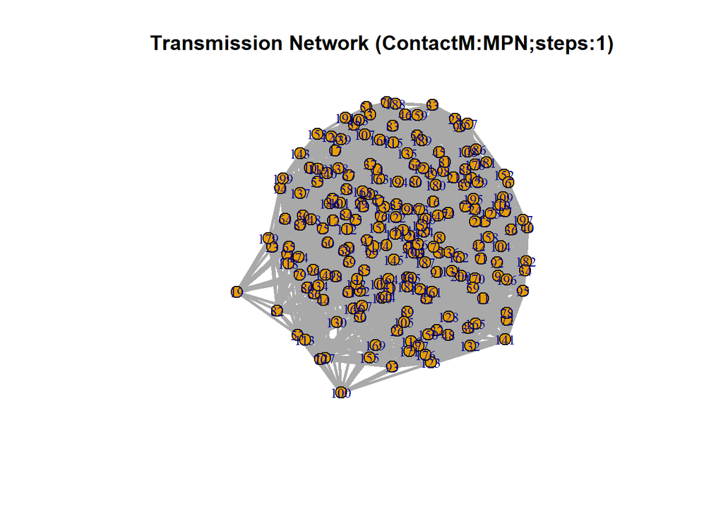

```r
plot(POP,type="cont.net", ContactM="MPN", steps=1)
```

Unlike the direct-contact network, this matrix is directed and therefore not necessarily symmetric. If individual $i$ uses an object before individual $j$, transmission may be possible from $i$ to $j$, but not necessarily from $j$ to $i$:

$$\phi_{ij}\neq\phi_{ji}.$$

### Homogeneous-mixing network

Finally, we simulate a homogeneous-mixing network (`NCN`) in which every individual is connected to every other individual with the same weight (`val`).

```r
POP=uniCONT(POP=POP,
  NameCont="NCN", # Name of the contact network (Naïve Contact Network)
  val=1           # Simulated values
)
```

The contact matrix is therefore:

$$\phi_{ij}=
\begin{cases}
1, & i\neq j\\
0, & i=j.
\end{cases}$$

This network provides a reference scenario in which transmission is not restricted by a particular contact structure. In terms of contact availability, it resembles the homogeneous-mixing individual-based model used previously because every infectious individual can potentially expose every susceptible individual.

The `simPOP` object now contains three alternative transmission structures:

```r
names(POP@ContactM)
```

```
## [1] "SIN" "MPN" "NCN"
```

### Simulate transmission through a network

We can now simulate disease transmission through one of these networks. We use the transmission ($\beta$) and recovery ($\gamma$) parameters from the `SimNet` vignette, selected to resemble the mastitis infection dynamics described by [Woudstra et al. (2023)](https://doi.org/10.3168/JDS.2022-22942).

```r
beta=0.000172244
gamma=0.0358299
```

For this example, transmission occurs through the object-mediated milking-parlour network (`MPN`). Setting `epsilon = NULL` means that recovered individuals immediately become susceptible again, producing an SIS model ($ SIS $).

```r
POP=SIRmod(POP=POP,
  NameCont="MPN",           # Name of the contact network
  beta=beta,
  gamma=gamma,
  epsilon=NULL,
  IDseed=sample(POP@IDs,7)  #Initial infected individuals (7)
)
```

### Visualize individual infection histories

The epidemiological status of every individual can be visualized for a selected simulation replicate.

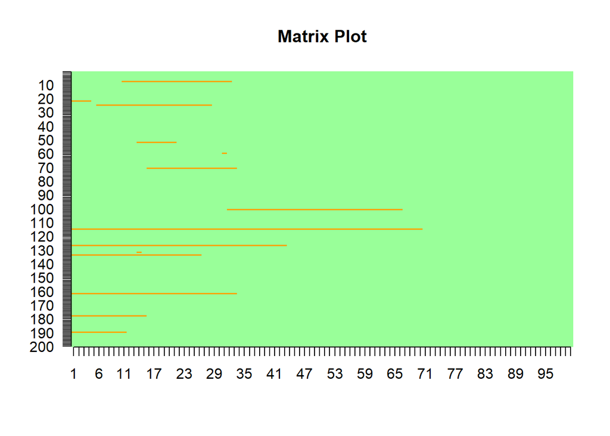

```r
plot(POP,rep=1,type="inf.mat")
```

Each row represents an individual and each column represents a simulation step, allowing us to follow infection and recovery events at the individual level.

### Visualize population-level dynamics

The individual infection histories can also be summarized across simulation replicates:

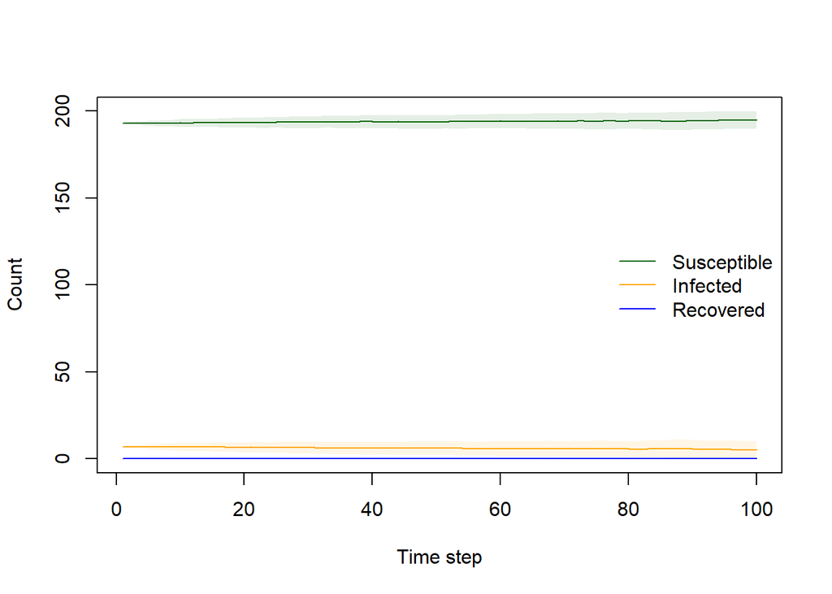

```r
plot(POP,type="inf.curv")
```

### Infer the most likely transmission network

In simulations, we know that the `MPN` network generated the infections. In real epidemiological data, however, the actual transmission route may be unknown. `RISKcont()` evaluates how compatible each observed infection event is with the available candidate contact networks.

Here, the homogeneous-mixing network (`NCN`) is used as the reference:

```r
POP=RISKcont(POP=POP,
  NameCont=names(POP@ContactM), # Candidate transmission networks
  ref="NCN",                    # Reference scenario (Baseline)
  verbose=FALSE
)
```

A transmission probability of zero indicates that an observed infection could not be explained by a particular network because there was no compatible contact with an infectious individual. We can summarize the proportion of impossible transmission events for each candidate network:

```r
tapply(POP@RISKcont$TProb,
       POP@RISKcont$ContactM,
       function(x) mean(x==0,na.rm=TRUE))
```

```
##         MPN         NCN         SIN
## 0.000000000 0.000000000 0.001036269
```

Finally, the relative support for each candidate transmission network can be visualized against the homogeneous-mixing reference.

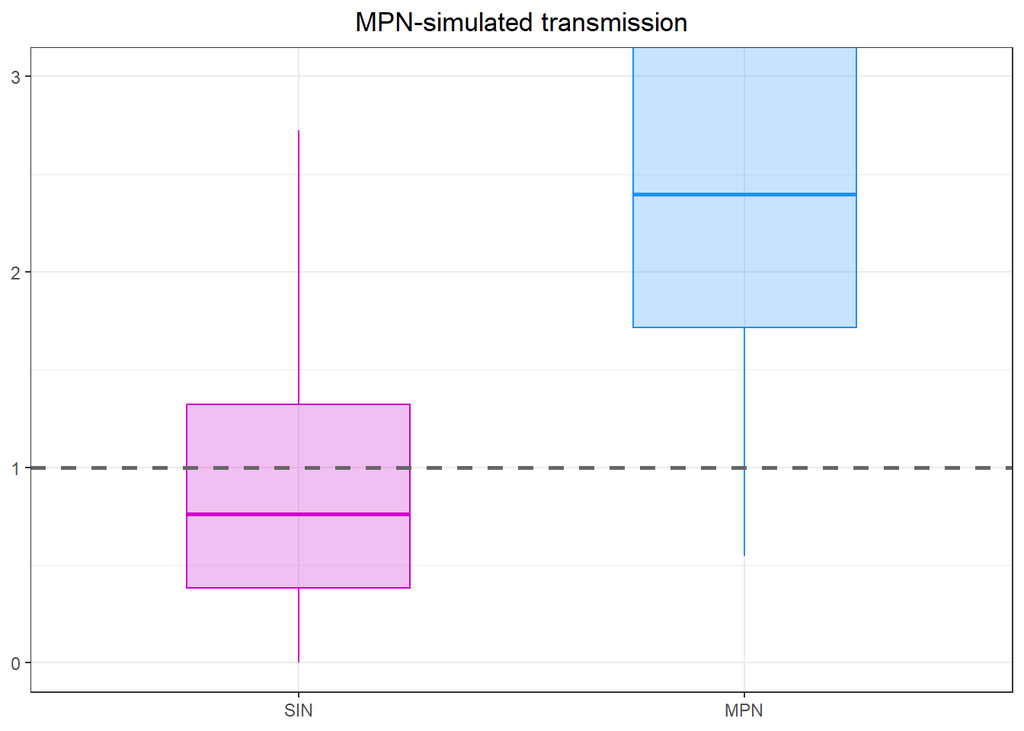

```r
plotRISKcont2(POP, ref="NCN", Nsim="MPN-simulated transmission")
```

Because transmission was simulated using the `MPN`, we can compare whether the inference procedure provides greater support for this network than for the alternative candidate transmission structures.

> **NOTE:** The analysis identifies the contact network that is most compatible with the observed infection events among the candidate networks provided. It does not demonstrate that the selected network is the only possible biological transmission route.

### Exercise 1: Exploring SimNet

Use the package documentation and the structure of the `simPOP` object to explore how different transmission scenarios can be simulated and analysed.

1. *Explore the `simPOP` object.*  
   Inspect the information stored in the object using:

   ```r
   POP
   slotNames(POP)
   names(POP@ContactM)
   length(POP@ContactM$SIN)
   dim(POP@ContactM$SIN[[1]])
   ```

   What information is stored in each part of the object? Use `ls("package:SimNet")` and the help pages to identify functions that we have not used yet. In particular, investigate `TPest()` and `RISKest()`.
2. *Number of initially infected individuals.*  
   Increase the number of individuals initially infected and simulate transmission using `"SIN"`. How does increasing the number of initial infections affect the epidemic dynamics?
3. *Can SimNet recover the causal network?*  
   Generate several independent contact networks with the same parameters but different names:

   ```r
   POP=simCONT(POP,NameCont="SIN1",gshape=1,gscale=5,rho=0.25,verbose=FALSE)
   POP=simCONT(POP,NameCont="SIN2",gshape=1,gscale=5,rho=0.25,verbose=FALSE)
   POP=simCONT(POP,NameCont="SIN3",gshape=1,gscale=5,rho=0.25,verbose=FALSE)
   ```

   Simulate transmission using only one of them and use `RISKcont()` to test whether the network used to generate the infections (causative transmission network) is still the one that achieved the maximum likelihood despite the presence of similar contact network structures.

   Then explore potential effective contacts using the function `RISKest()` and the causative network. Can `RISKest()` identify the individual that actually generated each simulated infection?
4. *Temporal stability.*  
   Repeat the previous exercise using networks with different temporal correlations, for example `rho=0`, `0.5`, and `0.9`. Does higher temporal stability improve or reduce the ability to identify the causal transmission network? Why might persistent contact patterns contain more or less information than rapidly changing contacts?
5. *Estimate the transmission parameters.*  
   The `TPest()` function can be used to estimate the values of $\beta$ and $\gamma$ from the status matrix. it implements the method described in previous exercises.

   ```r
   TP=TPest(POP)
   head(TP)
   ```

   POP@ContactM[["SIN_farms"]]=lapply(
       POP@ContactM[["SIN"]],
       function(M){
           # Remove contacts between farms
           M[outer(farm,farm,"!=")]=0
           diag(M)=0
           M
       }
   )

   heatmap(POP@ContactM[["SIN_farms"]][[1]],
       Colv = NA, Rowv = NA, symm = TRUE, revC = TRUE)
   ```

   The resulting network contains contacts within farms but no contacts between farms.

   Introduce infected individuals into one or several farms and simulate transmission through `"SIN_farms"`. Do the epidemic trajectories differ among farms?

   > **NOTE:** The $\beta$ and $\gamma$ values, as well as the weights and parameters used to generate the contact networks, have been carefully calibrated to resemble values observed in real data following Marina et al. and Woudstra et al. Small changes to these values may make the candidate networks no longer comparable and can therefore bias the inference of the causative transmission network.

## Incorporating breeding values into transmission models

### Simple simulation of genetic selection

Before incorporating breeding values into the transmission simulations, we will briefly illustrate the expected response to selection for traits with additive genetic variation that may represent individual susceptibility and infectivity. - Susceptibility is defined as the propensity of an individual to become infected when exposed to an infectious individual of average infectivity. - Infectivity is defined as the ability of an infected individual to transmit infection to a susceptible individual of average susceptibility.

Lets fix a random seed, again, to make the simulation reproducible.

```r
set.seed(123)
```

Let’s assume that breeding values for these traits follow a normal distribution with $\mu=0$ and an additive genetic standard deviation of $\sigma_A=0.10$. Both traits have a heritability of $h^2=0.05$. Heritability is defined as

$$h^2=\frac{\sigma_A^2}{\sigma_P^2},$$

where $\sigma_A^2$ is the additive genetic variance and $\sigma_P^2$ is the phenotypic variance.

```r
h2=0.05       # Heritability
sigma_A=0.10  # Additive genetic standard deviation
```

The relationship between the proportion and the intensity of selection can be estimated

```r
p=0.05   # Proportion selected
i=dnorm(qnorm(1-p))/p
i
```

```
## [1] 2.062713
```

```r
R=i*sqrt(h2)*sigma_A
```

The distribution of breeding values across 50 generations can be visualized as follows:

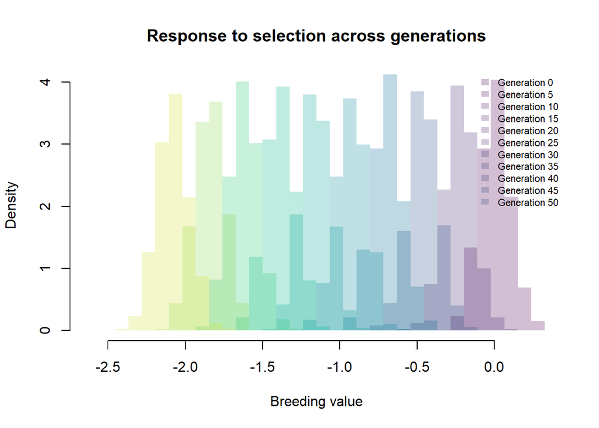

```r
N=1000
ngen=50 # Total number of generations

# BV distributions
BV_gen=vector("list",ngen+1)
for(g in 0:ngen) BV_gen[[g+1]]=rnorm(N, mean=-R*g, sd=sigma_A)
breaks=seq( min(unlist(BV_gen)), max(unlist(BV_gen)),length.out=35)


cols=adjustcolor(hcl.colors(ngen,"Viridis"),alpha.f=0.25)
hist(BV_gen[[1]], breaks=breaks, freq=FALSE,
     col=cols[1], border=NA,
     xlab="Breeding value",
     main="Response to selection across generations")

for(g in (seq(5,ngen,5)+1)){
  hist(BV_gen[[g]],breaks=breaks,freq=FALSE,
       col=cols[g],border=NA,add=TRUE)}

legend("topright", legend=paste0("Generation ",c(0,seq(5,ngen,5))),
       fill=cols, border=NA, bty="n", cex=0.7)
```

### Incorporating genetic selection into SimNet

We will now incorporate the expected genetic response to selection into a disease-transmission simulation. We simulate a farm with 200 individuals and three alternative contact structures: a social interaction network (`SIN`), an object-mediated milking-parlour network (`MPN`), and a homogeneous-mixing network (`NCN`).

Transmission will be simulated through the `MPN` using an SIS model, representing a persistent infection in which recovered individuals can become susceptible again.

```r
set.seed(123)

N=200

POP=simplePOP(NIDs=N,steps=100,rep=100)
POP=simCONT(POP=POP,NameCont="SIN", gshape=1,gscale=5,val=1,rho=0.25)
POP=simOBJ( POP=POP,NameCont="MPN", pos=24, freq=2, val=12)
POP=uniCONT(POP=POP,NameCont="NCN", val=1)
```

The transmission and recovery parameters are those used in the previous *SimNet* example.

```r
beta=0.000172244
gamma=0.0358299
NID_inf=sample(POP@IDs,7) # Intial infected individuals
```

### From breeding values to individual transmission risk

The additive genetic standard deviation is $\sigma_A=0.10$ and $h^2=0.05$. Therefore, the corresponding phenotypic and residual standard deviations are

$$\sigma_P=\frac{\sigma_A}{\sqrt{h^2}}$$

and

$$\sigma_E=\sqrt{\sigma_P^2-\sigma_A^2}.$$

```r
sigma_P=sigma_A/sqrt(h2)
sigma_E=sqrt(sigma_P^2-sigma_A^2)

cat("sigma_P:", sigma_P,"\n")
```

```
## sigma_P: 0.4472136
```

```r
cat("sigma_E:", sigma_E,"\n")
```

```
## sigma_E: 0.4358899
```

With the parameters used here, $\sigma_P\approx0.45$.

We first simulate susceptibility and infectivity breeding values for animals originating from the conventional production breeding line. Both traits have mean breeding value zero.

```r
BV_sus_prod=rnorm(N,mean=0,sd=sigma_A)
BV_inf_prod=rnorm(N,mean=0,sd=sigma_A)

E_sus=rnorm(N,mean=0,sd=sigma_E)
E_inf=rnorm(N,mean=0,sd=sigma_E)

P_sus_prod=BV_sus_prod+E_sus
P_inf_prod=BV_inf_prod+E_inf
```

For this exercise, phenotypic values are transformed into positive *relative transmission multipliers*:

$$w=2^{z/2},$$

where $p$ is the phenotypic value. A value of $p=0$ represents an average individual ($w=1$), $p=-1$ reduces the trait by approximately 29% ($w=0.71$), and $p=-2$ reduces it by 50% ($w=0.5$). Conversely, $p=+2$ doubles the relative susceptibility or infectivity ($w=2$).

Thus, lower phenotypic values correspond to lower susceptibility or infectivity while ensuring that all transmission multipliers remain positive.

```r
sus_prod=2^(P_sus_prod/2)
inf_prod=2^(P_inf_prod/2)
```

### Farmer 1: selection for lower susceptibility

The expected breeding-value distribution after 30 generations is already stored in `BV_gen[[31]]`, because the first element corresponds to generation 0.

```r
prop_sus=0.80
n_sus=round(N*prop_sus)

IDs_sus=sample(1:N,n_sus)

# Bulls from generation 30 of the susceptibility-selection line
sire_BV=sample(BV_gen[[31]],n_sus,replace=TRUE)

# Production-line dams
dam_BV=BV_sus_prod[IDs_sus]

# Expected progeny BV + Mendelian sampling
offspring_BV=(sire_BV+dam_BV)/2 + rnorm(n_sus,mean=0,sd=sigma_A/sqrt(2))

BV_sus_sel=BV_sus_prod
BV_sus_sel[IDs_sus]=offspring_BV
```

> **NOTE — Why add Mendelian sampling?**  
> The expected breeding value of an offspring is the average of the sire and dam breeding values, but full siblings do not inherit exactly the same combination of alleles. Mendelian sampling represents this random segregation of parental alleles and therefore creates genetic variation among offspring from the same parents. Without it, all offspring from the same sire–dam combination would receive exactly the same breeding value.

The phenotypic susceptibility of the resulting animals is then calculated using the same environmental component.

```r
P_sus_sel=BV_sus_sel+E_sus

sus_sel=2^(P_sus_sel/2)

cat("Production population:",mean(sus_prod),"\n")
```

```
## Production population: 1.013492
```

```r
cat("Selected progeny:", mean(sus_sel[IDs_sus]),"\n")
```

```
## Selected progeny: 0.8013227
```

### Farmer 2: selection for lower infectivity

A second farmer instead decides that 70% of future animals will descend from bulls selected for lower infectivity after 40 generations.

```r
prop_inf=0.70
n_inf=round(N*prop_inf)

IDs_inf=sample(1:N,n_inf)

# Bulls from generation 40 of the infectivity-selection line
sire_BV=sample(BV_gen[[41]],n_inf,replace=TRUE)

# Production-line dams
dam_BV=BV_inf_prod[IDs_inf]

offspring_BV=(sire_BV+dam_BV)/2 + rnorm(n_inf,mean=0,sd=sigma_A/sqrt(2))

BV_inf_sel=BV_inf_prod
BV_inf_sel[IDs_inf]=offspring_BV

P_inf_sel=BV_inf_sel+E_inf

inf_sel=2^(P_inf_sel/2)

cat("Production population:",mean(inf_prod),"\n")
```

```
## Production population: 1.008676
```

```r
cat("Selected progeny:", mean(inf_sel[IDs_inf]),"\n")
```

```
## Selected progeny: 0.7357067
```